# Lending Club Loan Visualization

## Introduction

### Lending Club is a leading peer-to-peer lender

### How it works:

- Lending Club uses potential borrowers' credit history to estimate credit risk (the risk of not being paid back)
- This credit risk estimate is used to set the interest rate – higher risk, higher return
- Lenders (e.g., you and I) then choose which loans to fund at the LC-prescribed rate

#### Analyzed historical lending data available on the LC website

[figure not shown]

## Why do people use Lending Club?

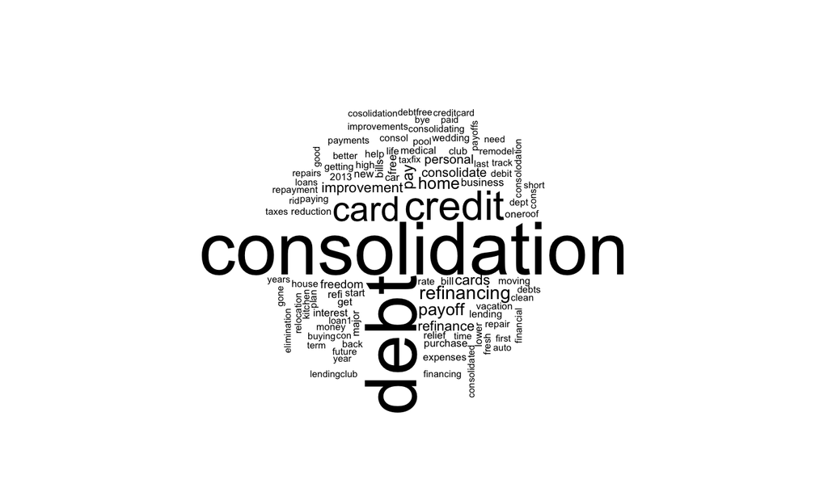

Most borrowing is used to repay existing debt

## Loan Grade Drives Interest Rate

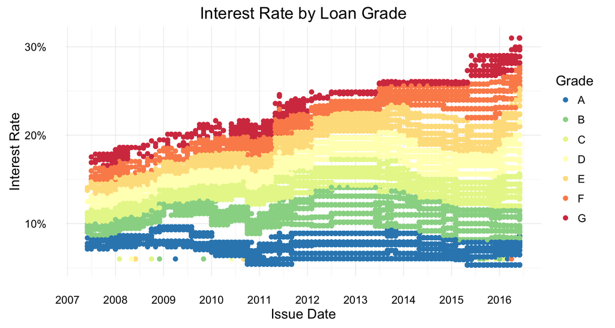

## Credit Profile Trends

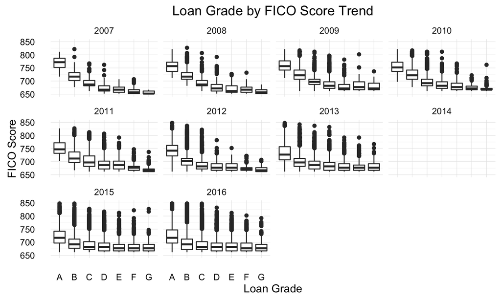

Less dependence on FICO scores over the years

## Smarter Lending at the Lending Club?

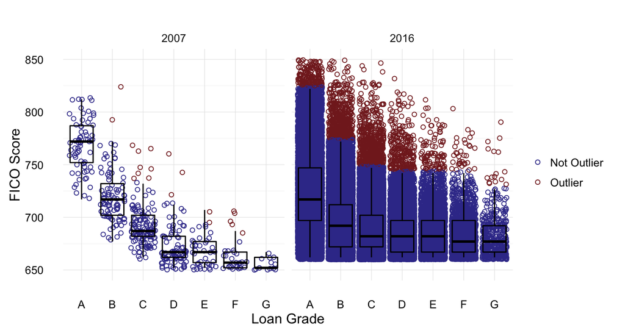

Breaking the FICO mould:  
- Borrowers with lower FICO scores paying low interest rates  
- Borrowers with excellent FICO scores paying high interest rates ("outliers")  
- Is Lending Club making a mistake?

## Outliers Belong in their Buckets

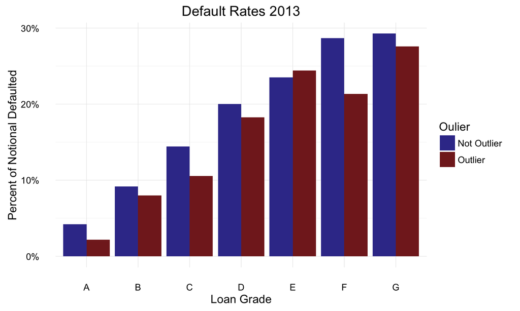

## What's Bad about the Outliers?

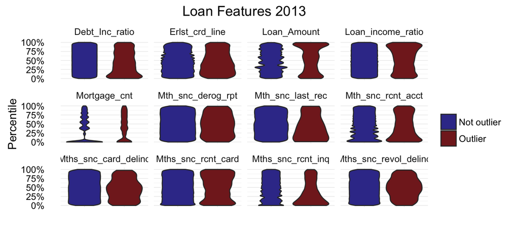

Slight bias towards:  
- Higher nominal loan amounts  
- Higher loan amounts as proportion of income  
- Increased indicators of economic distress (recently opened a new credit line, recent credit inquiries)

## Conclusion

#### Takeaways

- FICO still matters — lend to them instead of lower scored borrowers in the same loan grade
- Specific driver of getting bumped down a grade not determined

#### Next Steps

- Bootcamp 6's Kaggle winners used training data that had additional useful information about the borrowers that is not in the publically available data — what is LC keeping from us?
- Multivariate analysis — possibly a set of themes for getting put in the outlier credit doghouse
- Integration of denied loan request data
- Analysis of low FICO, high LC grade loans